# Part II - Present Slide Dect

## by (THUYTTT17@FPT.COM)

### Investigation Overview

In this investigation, the focus is on understanding how various features of loans influence or predict a borrower’s APR (Annual Percentage Rate). The analysis aims to uncover how specific variables impact the APR and the dynamics between APR and other factors. Key areas of interest include examining the relationship between APR and loan amount, APR and borrower rating, and how loan term affects these relationships. The categorical variables under consideration are 'LoanStatus', 'IncomeVerifiable', 'EmploymentStatus', 'Term', and 'ProsperRating (Alpha)', while the numeric variables of interest include 'BorrowerAPR', 'StatedMonthlyIncome','Term', 'LoanOriginalAmount', and 'DebtToIncomeRatio'.

### Dataset Overview

The dataset comprises 113,937 loans with 81 distinct variables recorded for each loan, including details such as loan amount, borrower rate, current loan status, and borrower income. This dataset, provided by Prosper via Udacity, contains a broad array of data points, including 799 rows identified as anomalies. Rather than excluding these rows, they have been included in the analysis to explore their impact and gain deeper insights into these unusual cases within the dataset

```python
# import all packages and set plots to be embedded inline
import numpy as np
import pandas as pd
import matplotlib.pyplot as plt
import seaborn as sb

%matplotlib inline

# suppress warnings from final output
import warnings
warnings.simplefilter("ignore")
```

```python
import pandas as pd

# Load the dataset into a pandas dataframe
loan_df = pd.read_csv('prosperLoanData.csv')

# Subset the dataframe with the new columns
cols = ['LoanStatus', 'BorrowerAPR', 'EmploymentStatus', 'StatedMonthlyIncome',
        'IncomeVerifiable', 'DebtToIncomeRatio', 'LoanOriginalAmount', 'Term',
        'ProsperRating (Alpha)', 'ProsperRating (numeric)', 'CreditGrade',
        'BorrowerRate', 'EstimatedEffectiveYield', 'EstimatedLoss', 'EstimatedReturn']
loan_subset = loan_df[cols]

# Handle missing values if necessary
# Example: Fill missing values or drop rows/columns with missing values
loan_subset = loan_subset.dropna(subset=['LoanStatus', 'IncomeVerifiable', 'EmploymentStatus', 'Term'])

# Group all values in "LoanStatus" containing "Past Due " and replace with "Past Due"
loan_subset.loc[loan_subset['LoanStatus'].str.contains('Past Due '), 'LoanStatus'] = 'Past Due'

# Convert 'LoanStatus' to categorical with ordered categories
loanstatus_order = loan_subset['LoanStatus'].value_counts().index
ordered_var = pd.api.types.CategoricalDtype(ordered=True, categories=loanstatus_order)
loan_subset['LoanStatus'] = loan_subset['LoanStatus'].astype(ordered_var)

# Convert 'IncomeVerifiable' to categorical with ordered categories
income_order = loan_subset['IncomeVerifiable'].value_counts().index
ordered_var = pd.api.types.CategoricalDtype(ordered=True, categories=income_order)
loan_subset['IncomeVerifiable'] = loan_subset['IncomeVerifiable'].astype(ordered_var)

# Convert 'EmploymentStatus' to categorical with ordered categories
employ_order = loan_subset['EmploymentStatus'].value_counts().index
ordered_var = pd.api.types.CategoricalDtype(ordered=True, categories=employ_order)
loan_subset['EmploymentStatus'] = loan_subset['EmploymentStatus'].astype(ordered_var)

# Convert 'Term' to categorical with ordered categories
term_order = [12, 36, 60]
ordered_var = pd.api.types.CategoricalDtype(ordered=True, categories=term_order)
loan_subset['Term'] = loan_subset['Term'].astype(ordered_var)

# Convert 'ProsperRating (Alpha)' to categorical with ordered categories
rating_order = ['HR', 'E', 'D', 'C', 'B', 'A', 'AA']
ordered_var = pd.api.types.CategoricalDtype(categories=rating_order, ordered=True)
loan_subset['ProsperRating (Alpha)'] = loan_subset['ProsperRating (Alpha)'].astype(ordered_var)

# Convert 'ProsperRating (numeric)' to numeric if it's not already
loan_subset['ProsperRating (numeric)'] = pd.to_numeric(loan_subset['ProsperRating (numeric)'], errors='coerce')

# Convert 'CreditGrade' to categorical (if applicable)
loan_subset['CreditGrade'] = loan_subset['CreditGrade'].astype('category')

# Handle missing values for numeric columns
loan_subset['BorrowerAPR'] = loan_subset['BorrowerAPR'].fillna(loan_subset['BorrowerAPR'].median())
loan_subset['StatedMonthlyIncome'] = loan_subset['StatedMonthlyIncome'].fillna(loan_subset['StatedMonthlyIncome'].median())
loan_subset['DebtToIncomeRatio'] = loan_subset['DebtToIncomeRatio'].fillna(loan_subset['DebtToIncomeRatio'].median())
loan_subset['LoanOriginalAmount'] = loan_subset['LoanOriginalAmount'].fillna(loan_subset['LoanOriginalAmount'].median())
loan_subset['BorrowerRate'] = loan_subset['BorrowerRate'].fillna(loan_subset['BorrowerRate'].median())
loan_subset['EstimatedEffectiveYield'] = loan_subset['EstimatedEffectiveYield'].fillna(loan_subset['EstimatedEffectiveYield'].median())
loan_subset['EstimatedLoss'] = loan_subset['EstimatedLoss'].fillna(loan_subset['EstimatedLoss'].median())
loan_subset['EstimatedReturn'] = loan_subset['EstimatedReturn'].fillna(loan_subset['EstimatedReturn'].median())

# Check the shape of the subset dataframe
print(loan_subset.shape)

# Display the first few rows of the dataframe to verify
print(loan_subset.head())
```

```
(111682, 15)
  LoanStatus  BorrowerAPR EmploymentStatus  StatedMonthlyIncome  \
0  Completed      0.16516    Self-employed          3083.333333
1    Current      0.12016         Employed          6125.000000
2  Completed      0.28269    Not available          2083.333333
3    Current      0.12528         Employed          2875.000000
4    Current      0.24614         Employed          9583.333333

  IncomeVerifiable  DebtToIncomeRatio  LoanOriginalAmount Term  \
0             True               0.17                9425   36
1             True               0.18               10000   36
2             True               0.06                3001   36
3             True               0.15               10000   36
4             True               0.26               15000   36

  ProsperRating (Alpha)  ProsperRating (numeric) CreditGrade  BorrowerRate  \
0                   NaN                      NaN           C        0.1580
1                     A                      6.0         NaN        0.0920
2                   NaN                      NaN          HR        0.2750
3                     A                      6.0         NaN        0.0974
4                     D                      3.0         NaN        0.2085

   EstimatedEffectiveYield  EstimatedLoss  EstimatedReturn
0                  0.16150         0.0724          0.09170
1                  0.07960         0.0249          0.05470
2                  0.16150         0.0724          0.09170
3                  0.08490         0.0249          0.06000
4                  0.18316         0.0925          0.09066
```

> Note that the above cells have been set as "Skip"-type slides. That means that when the notebook is rendered as http slides, those cells won't show up.

### Borrower APR Distribution

The distribution of Borrower APR shows multiple modes with small peaks at 0.1 and a more prominent peak at 0.2. Following this peak, the distribution trends downward, with another notable peak at 0.3 and a sharp spike at 0.35. Loans with APRs exceeding 0.42 are rare, indicating that most loans fall within the lower APR range.

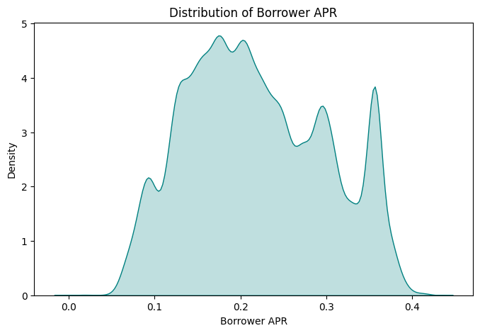

```python
import seaborn as sns
import matplotlib.pyplot as plt
from matplotlib import rcParams

# Set the figure size
rcParams['figure.figsize'] = 8, 5

# Create the KDE plot
sns.kdeplot(data=loan_subset, x='BorrowerAPR', fill=True, color='teal')

# Set plot labels and title
plt.xlabel('Borrower APR')
plt.ylabel('Density')
plt.title('Distribution of Borrower APR')

# Show the plot
plt.grid(False)
plt.show()
```

### Heatmap of Numeric Values

Key Observations:

Debt-to-Income Ratio and Stated Monthly Income: This pair shows a negative correlation, implying that as the stated monthly income increases, the debt-to-income ratio tends to decrease. This aligns with the expectation that higher income should reduce the proportion of income spent on debt.

LoanOriginalAmount and Stated Monthly Income: A positive correlation of 0.20 is observed here, indicating that higher stated monthly income is associated with larger loan amounts. This is intuitive as higher income levels typically qualify borrowers for larger loans.

The heatmap provides a visual representation of these relationships, highlighting how changes in one variable might be associated with changes in another. The use of the 'coolwarm' color map aids in distinguishing between positive and negative correlations.

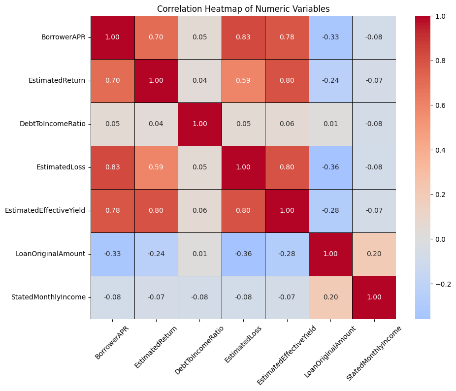

```python
import seaborn as sb
import matplotlib.pyplot as plt

# Define the numeric variables
num_var = ['BorrowerAPR', 'EstimatedReturn', 'DebtToIncomeRatio', 'EstimatedLoss','EstimatedEffectiveYield', 'LoanOriginalAmount', 'StatedMonthlyIncome']

# Create a heatmap with a different color map
plt.figure(figsize=[10, 8])
sb.heatmap(loan_subset[num_var].corr(), annot=True, fmt='0.2f',
          cmap='coolwarm', center=0, linewidths=0.5, linecolor='black')

# Rotate x-ticks for better readability
plt.xticks(rotation=45)

# Set the title of the heatmap
plt.title('Correlation Heatmap of Numeric Variables')

# Show the plot
plt.show()
```